```python
# junk for jupyter notebook
%matplotlib inline
%load_ext autoreload
%autoreload 2
```

The imports below are fairly standard for my work - I just copy and paste them into a new notebook, generally.

All my personal tools (ncdiag, gmao_tools, simple_obsplot) can be accessed here: https://github.com/will-mccarty/das_tools/tree/master/python_tools

```python
#standard imports (I just copy and paste this into most notebooks)
import numpy as np
import matplotlib.pyplot as plt
import ncdiag as ncd
import gmao_tools as gt
import matplotlib
#font = {'family' : 'normal',
#        'size'   : 18}

#matplotlib.rc('font', **font)

import simple_obsplot as sop
import cartopy.crs as ccrs
```

This is a pretty basic walk-through of the `ncdiag.py` module. It really isn't anything fancy, but it's how I interact with data. Hopefully, this serves as a use case of where power users need direct access to the data. Specifically, something between the raw data living in IODALand, but prior to a one-size-fits-all, end use GUI.

In all practical purposes, this intermediate level of interfacing with the data could also be used to generate customizable plots and tools that could be propagated upward to the GUI-level.

OK - Let's open a single file

```python
ro_file = ncd.obs('x0042c2.diag_conv_gps_ges.20191201_00z.nc4')
```

For a lot of these examples, I'm going to use a 'simple_obsplot' module, which is really just a few plotting shortcuts/routines. FOr example, `plot_obs_map` really just plots lon v. lat on a cartopy projection. Nothing fancy.

The plot below shows all the data in this one RO file

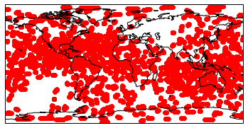

```python
sop.plot_obs_map(ro_file)
```

OK - now we want to plot the COSMIC-2 data, which has an `Observation_Type` between 750 & 755. Here, we can use the mask feature, which just uses a string of logic to 'select' the data.

Note: It would have been more proper to call this a select routine than a mask routine, as it returns values that match the logical string (all data points that are `True` )

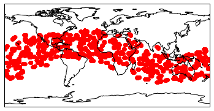

```python
msk = '(Observation_Type > 750) & (Observation_Type < 755)'
ro_file.set_mask(msk)
ro_file.use_mask(True)
sop.plot_obs_map(ro_file)
```

I'm lazy; typing `Observation_Type` is very tedious. At GMAO, we use the shorthand `kx`, which is also used in places within the GSI. Within the `ncdiag` module, I made a quick shortcut dictionary that allows shorthand:

```
varmap = {
    'lat':   'Latitude'         ,
    'lon':   'Longitude'        ,
    'kx':     'Observation_Type' ,
    'subtype':'Observation_Subtype',
...
    'ee':     'Height'}
```

So this is equivalent:

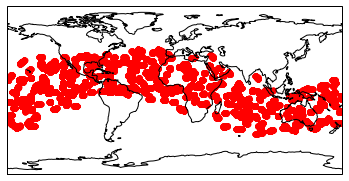

```python
msk = '(kx > 750) & (kx < 755)'
ro_file.set_mask(msk)
ro_file.use_mask(True)
sop.plot_obs_map(ro_file)
```

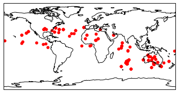

```python
msk = '(kx > 750) & (kx < 755) & (Height < 2500) & (used == 1)'
ro_file.set_mask(msk)
ro_file.use_mask(True)
sop.plot_obs_map(ro_file)
```

Let's plot a quick histogram of O-B for the data below 2.5 km, assimilated or rejected.

Note: At GMAO, the O-F (obs minus forecast) nomenclature dominates, so I tend to use O-B and O-F interchangably

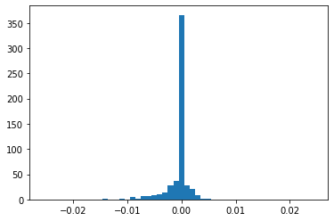

```python
msk = '(kx > 750) & (kx < 755) & (Height < 2500)'
ro_file.set_mask(msk)
ro_file.use_mask(True)

cur_omf = ro_file.v('omf')
bins = gt.bins(-0.025,0.025,0.001) # a simple routine I have to define bins by min/max/size

h = plt.hist(cur_omf,bins=bins)
plt.show()
```

In all reality, I don't often look at one file at a time, but rather some timeseries of files...

I've created an `obs_template` class, which is basically on top of `obs`. As an input, it takes a templated string, a startdate, and an enddate.

```python
startdate=2019120100
enddate=2019120118

ro_tmpl = ncd.obs_template('x0042c2.diag_conv_gps_ges.$yyyy$mm${dd}_${hh}z.nc4',startdate=startdate,enddate=enddate)
```

Otherwise, the usage is the same. Let's plot all of the COSMIC-2 data

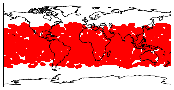

```python
msk = '(kx > 750) & (kx < 755)'
ro_tmpl.set_mask(msk)
ro_tmpl.use_mask(True)
sop.plot_obs_map(ro_tmpl)
```

Or that same histogram:

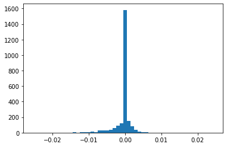

```python
msk = '(kx > 750) & (kx < 755) & (Height < 2500)'
ro_tmpl.set_mask(msk)
ro_tmpl.use_mask(True)

cur_omf = ro_tmpl.v('omf')
bins = gt.bins(-0.025,0.025,0.001) # a simple routine I have to define bins by min/max/size

h = plt.hist(cur_omf,bins=bins)
plt.show()
```

I've also wired in the ability to do derived calculations. For example in RO space, we often look at (O-B)/B. I have a `derived_var` dictionary that treats calculations as variables within the file:

```
derived_var = {
    'amb':         {'func': ncf.amb,          'deps': ['omf','oma']},
    'fcst':        {'func': ncf.fcst,         'deps': ['omf','obs']},
...    'omfbyo':      {'func': ncf.omfbyo,       'deps': ['omf','obs']},
    'omfbyf':      {'func': ncf.omfbyf,       'deps': ['omf','obs']}
    }
```

So let's plot the `omfbyf` histogram for all used observations:

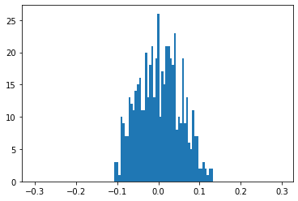

```python
msk = '(kx > 750) & (kx < 755) & (Height < 2500) & (used == 1)'
ro_tmpl.set_mask(msk)
ro_tmpl.use_mask(True)

cur_omf = ro_tmpl.v('omfbyf')
bins = gt.bins(-0.3,0.3,0.005) # a simple routine I have to define bins by min/max/size

h = plt.hist(cur_omf,bins=bins)
plt.show()
```

Finally, some stats. Again, the derived stats are defined in a dictionary:

```
stats = {
    'mean':        {'func': np.mean,          'deps': None} ,
    'absmean':     {'func': ncf.absmean,      'deps': None} ,
    'std':         {'func': np.std,           'deps': None} ,
    'count':       {'func': len,              'deps': None} ,
    'sum':         {'func': np.sum,           'deps': None} ,
    'cpen':        {'func': ncf.cpen,         'deps': ['sigo']} ,
    'rms':         {'func': ncf.rms,          'deps': None} }
```

You can either get the bulk stat:

```python
print('omfbyf mean: ',ro_tmpl.stat('mean','omfbyf'))
```

```
omfbyf mean:  0.002731518
```

Or the timeseries:

```python
print('omfbyf mean timeseries: ')
dates, vals = ro_tmpl.stat_ts('mean','omfbyf')
print('dates: ',dates)
print('vals: ', vals)

print('or by dataframe....')
df = ro_tmpl.stat_ts('mean','omfbyf',DataFrame=True)
df
```

```
omfbyf mean timeseries:
dates:  [2019120100 2019120106 2019120112 2019120118]
vals:  [-0.00517965  0.00532434  0.00219657  0.00838043]
or by dataframe....
```

|  | ndate | Val | datetime |
| --- | --- | --- | --- |
| 0 | 2019120100 | -0.005180 | 2019-12-01 00:00:00 |
| 1 | 2019120106 | 0.005324 | 2019-12-01 06:00:00 |
| 2 | 2019120112 | 0.002197 | 2019-12-01 12:00:00 |
| 3 | 2019120118 | 0.008380 | 2019-12-01 18:00:00 |

Finally, I do have a tool that does a better job spatially aggregating data. A simple, rectangular grid of equal-lat & equal-lon will not do a good job showing the poles. Instead, I have this plotting routine, which attempts to grid to grid boxes of equal spatial area.

I'll just do all used RO between 10-12 km for this:

```python
msk = '(used == 1) & (Height > 10000) & (Height < 12000)'
ro_tmpl.set_mask(msk)
```

First - we'll plot the spatial histogram (used obs per box, if you will)

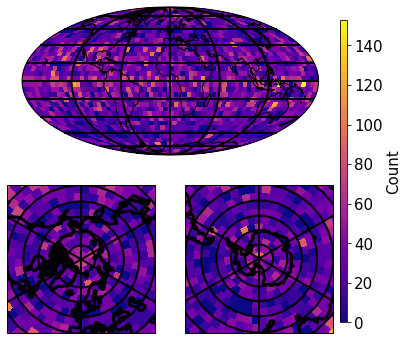

```python
lons = ro_tmpl.v('lon')
lats = ro_tmpl.v('lat')

sop.plot_spatial_gauss_hist(lons,lats,deltalat=5.0)
```

Or we can look at the spatial mean of Observation Error:

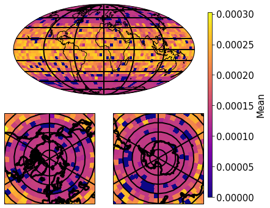

```python
lons = ro_tmpl.v('lon')
lats = ro_tmpl.v('lat')
sigo = ro_tmpl.v('sigo')

sop.plot_spatial_gauss_mean(lons,lats,sigo,deltalat=5.0)
```